# Coursework Report

*N* removed NAs: 2

*N* removed typo: 1

*N* removed <18: 26

*N* total clean: 121

| Group | *N* | *M*<sub>age</sub> | *M*<sub>rating</sub> |
| --- | --- | --- | --- |
| Control | 66 | 21.36 | 7.73 |
| Experim | 55 | 21.24 | 6.26 |

**Main analysis results**

*t*(119) = 11.11, *p* < .001

[interactive chart not shown]

[figure not shown]

[interactive chart not shown]

# Coursework Report

Analysing Data, Spring 2020

# Methods

## Participants

Fig 1. Participants

| Group | n | Mean Age | SD Age |
| --- | --- | --- | --- |
| control | 76 | 24.39 | 32.16 |
| experimental | 72 | 19.74 | 3.72 |

## Design

This study was an attempt to explore the effect of the colour red on perceived attractiveness. Specifically, the effect of the colour red on female perceptions of male attractiveness. The design of this study was a replication of *Experiment One* of Elliot et al. (2010).

In total, 148 female participants were randomly allocated to either the experimental condition or the control condition. All participants were asked to take part within a lab setting. In both conditions, participants were presented a black-and-white portrait photo of a moderately attractive Caucasian man. However, in the experimental condition, participants were presented this photo on a red border, and in the control condition, participants were presented this photo on a white border. All participants were then asked to answer three questions based upon perceived attractiveness. The three questions were as followed: *“How attractive do you think this person is?”*, *“How pleasant is this person to look at?”*, and *“If I were to meet the person in this picture face to face, I would think he is attractive”*. Participants were then asked to rate each item on a 9-point scale (with 1 being *not attractive at all* and 9 being *extremely attractive*).

Due to the findings of the original study (Elliot et al., 2010) it was expected that there would be a difference between the two conditions. Specifically, it was expected that there would be a higher mean attractiveness rating in the experimental (red) condition than in the control (white) condition. In order to analyse the results of this study, an independent-samples *t*-test was used to determine how the colour red influences perceived attractiveness.

# Results

The results of this study were analysed using an independent measures *t*-test. The scores collected from the study are shown in the table below.

Fig 2. Attractiveness Ratings

| Condition | Mean Attractiveness Rating 1 | Mean Attractiveness Rating 2 | Mean Attractiveness Rating 3 | Mean Composite Attractiveness Rating |
| --- | --- | --- | --- | --- |
| control | 7.921053 | 7.447368 | 7.842105 | 7.74 |
| experimental | 6.250000 | 6.208333 | 6.347222 | 6.27 |

It was found that the mean composite score of attractiveness ratings in the control condition was (*M*<sub>control</sub> = 7.74)). The mean composite score of attractiveness ratings in the experimental condition was (*M*<sub>experimental</sub> = 6.27). In other words, the white background was found to be correlated with increased ratings of attractiveness. The difference in means was significant (*M*<sub>diff</sub> = 1.47, 95% CI [1.23, 1.71], *t* (146) = 12.2, *p* = 0).

These results suggest that the null hypothesis should be rejected and the alternative hypothesis should be accepted. This is because there is a significant difference in the sample means (*M*<sub>diff</sub> =1.47). The *t*-test revealed that it would be very unlikely to obtain a *t* value as large or larger than *t* (146) = 12.2. The probability *p* of this occurring is *p* = 0. Due to this p-value being extremely small, it suggests that there is a real difference between the control and experimental sample populations, and that the two populations do not overlap. Therefore, it can be concluded that the two sample means come from two different populations. This means that the null hypothesis can be rejected, and the alternative hypothesis can be accepted. In conclusion, the analysis suggests that the colour of the border (either red or white) does have a significant impact on perceived attractiveness of males from a female perspective. However, the results did not show the same pattern as the original study. While Elliot et al. (2010) found that the colour red was associated with increased attractiveness ratings, the present study found that white was associated with increased attractiveness ratings. The results of the present study are summarised in the graph below.

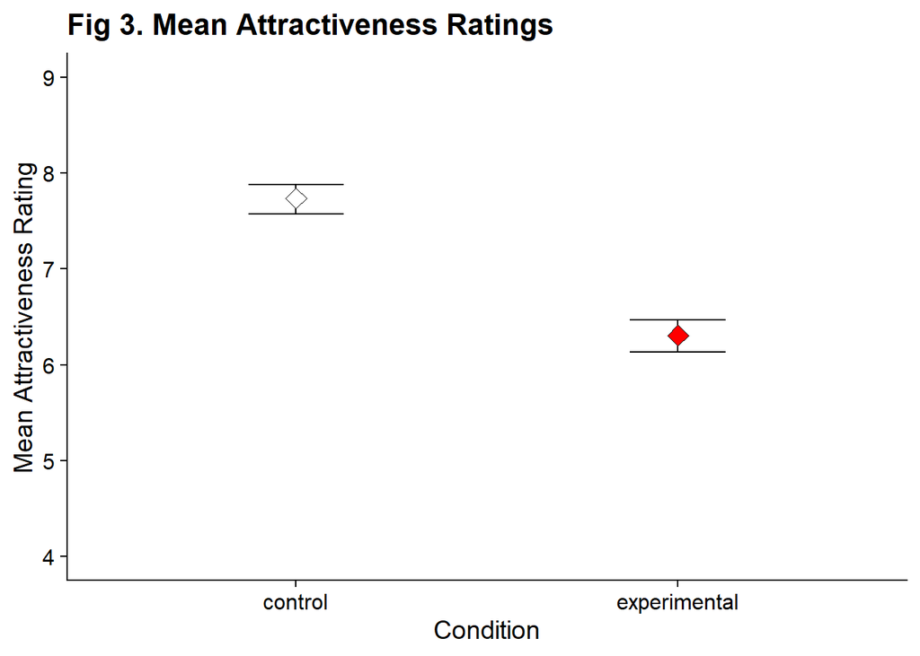

# Discussion

## Summary

This study was an attempt to explore the effect of the colour red on perceived attractiveness. An independent design was used and the results were analysed using an independent-samples *t*-test. The results found that females gave higher attractiveness ratings for a photo of a male on a white background than on a red background. A *t*-test was then used to show that the results were significant and that it was highly likely that this sample was an accurate reflection of the wider population.

## Implications

The results of this study suggest that women rate men as being more attractive when they are paired with the colour white than if they are paired with the colour red. This is unexpected as the original study (Elliot et al., 2010) suggested that red is associated with increased attractiveness ratings. However, there seems to be some inconsistency in the findings of studies within this field. While some earlier studies have claimed that red is correlated with higher perceived attractiveness, such as Elliot et al. (2010), some more recent studies have disputed this finding.

Elliot et al. (2010) completed an extensive study, consisting of 7 experiments, that demonstrated that women perceived men to be more attractive when they are shown on a red background than when they are shown on a white background. Similar findings were also found when the man was wearing red clothing compared to when the man was wearing white clothing (Elliot et al., 2010). It was additionally suggested that this ‘red effect’ occurs due to perceived higher status.

However, Hesslinger, Golbach and Carbon (2015) revisited the findings from the Elliot et al. (2010) study and found that the results were not as robust as they were claimed to be. Hesslinger, Golbach and Carbon (2015) completed a broader study that included multiple different men wearing either formal or casual clothing. No significant impact of red on perceived attractiveness was found. Instead, a significant effect of clothing style on attractiveness ratings was found. Attractiveness ratings were found to be higher for men wearing more formal attire compared to men wearing more casual attire. This finding deeply questioned the reliability and robustness of the findings from the Elliot et al. (2010) study. Indeed, Hesslinger, Golbach and Carbon (2015) suggested that Elliot et al. (2010) had, by creating a highly controlled and relatively narrow study, failed to take into account other contributing factors such as clothing style. The findings from Hesslinger, Golbach and Carbon (2015) support the results of the present study.

Another, arguably more in-depth, study from Peperkoorn, Roberts and Pollet (2016) found further evidence to suggest that red does not increase perceived attractiveness. In this study, 206 male students were asked to rate the attractiveness of a photo of a woman in either a red, black, or white t-shirt. The results suggested that significantly higher attractiveness ratings were given to women wearing white, compared to those wearing red. These results further support the findings of the present study.

Overall, these more recent studies support the findings of the present study. It appears that red does not have a significant effect on perceived attractiveness. At a minimum, the ‘red effect’ does not appear to be widely found across different studies. Indeed, there is limited evidence to suggest that the earlier studies are reliable as they show low ecological validity and poor replicability. Therefore, based upon the results and analysis of this study, as well as previous studies, there is no conclusive evidence to suggest that the ‘red effect’ is real. Despite the lack of conclusive evidence of the ‘red effect’, there is still evidence from this study, as well as other similar studies, that colours do have an effect on perceived attractiveness. Therefore, this research question should be investigated further.

## Limitations

One limitation of this study was that it was performed in a lab setting, meaning that it is unclear how ecologically valid these results are. Therefore, it is unclear to what extent these results would be representative of a more natural setting. This could potentially be resolved in future studies by collecting data from a fake dating app, or some other means that is more representative of a real life scenario.

Another limitation is that this study did not determine whether participants were aware of the aim of the study. Therefore, it is unclear whether there are any participant effects. This could be easily resolved in a future study by asking participants at the end of the study, during the debrief, what they believed the aim of the study to be.

Furthermore, this study used self-report as the method of data collection. Self-report is inherently unreliable as it is vulnerable to participant effects. Therefore, it is unclear to what extent the results are truly representative. Future studies could potentially resolve this issue by using more objective measures such as pupil dilation or heart rate.

## Future Research

In future studies, other factors could be considered as well as colour. For example, Peperkoorn, Roberts and Pollet (2016) compared how facial expression, clothing, and colour all effected perceived attractiveness. This would give a more complete understanding of the factors affecting attraction.

Furthermore, future studies could attempt to discern why certain colours have an affect on attractiveness ratings. This would provide a broader understanding of the effects that colours have on people. Multiple studies have shown the associations people make with certain colours. For example, the colour red is perceived as threatening (Wiedemann et al., 2015). Therefore, it is possible that red may reduce attractiveness ratings due to being associated with aggression or threat. This could provide real explanation for the results of the present study.

Future studies may also want to use a larger variety of questions. This would allow for a more reliable and in-depth analysis of the attractiveness ratings. For example, a larger variety of questions could allow for distinction between attraction and likeability as shown in other experiments completed by Elliot et al. (2010). This would provide more insight into specifically which aspects of thought are being affected by the different colours used in the study.

## Conclusion

The present study explored the effect of the colour red on perceived attractiveness ratings. It was found that women gave higher attractiveness ratings of a photo of a man on a white background than on a red background. This suggests that women perceive men to be more attractive when they are paired with the colour white than when they are paired with the colour red. This indicates that there is not conclusive evidence on the existence of the ‘red effect’. Despite this, there is still evidence to suggest that colours do have an effect on perceived attractiveness. Therefore, further investigation should be completed on this research question.

# References

Elliot, A. J., Niesta Kayser, D., Greitemeyer, T., Lichtenfeld, S., Gramzow, R. H., Maier, M. A., & Liu, H. (2010). Red, rank, and romance in women viewing men. Journal of Experimental Psychology: General, 139(3), 399.

Hesslinger, V. M., Goldbach, L., & Carbon, C. C. (2015). Men in red: A reexamination of the red-attractiveness effect. Psychonomic bulletin & review, 22(4), 1142-1148.

Peperkoorn, L. S., Roberts, S. C., & Pollet, T. V. (2016). Revisiting the red effect on attractiveness and sexual receptivity: No effect of the color red on human mate preferences. Evolutionary Psychology, 14(4), 1474704916673841.

Wiedemann, D., Burt, D. M., Hill, R. A., & Barton, R. A. (2015). Red clothing increases perceived dominance, aggression and anger. Biology letters, 11(5), 20150166.